Financial Analytics · Investment Intelligence

# Financial Investment Analysis Report

A data-driven analysis of 3,845 companies using 2018 financial data — examining stock performance, company valuation, and predictions for 2019 investment spending.

Companies Analysed3,845

Data Year2018 Financial Reports

Prediction TargetInvestment Spending 2019

Written forNon-Technical Readers

Section 01

## Plain-English Summary

*Read this section first — it gives you the full picture without any technical detail.*

**⚡ The Central Finding:** A company's past financial performance — especially its operating income, book value, and previous investment levels — is a strong predictor of how much it will invest the following year. The model built here predicts 2019 investment spending with a correlation of **0.921**, meaning its predictions closely track what companies actually spent.

### What This Project Did

We analysed the financial records of **3,845 companies** from 2018. For each company, we looked at measures like their total market value, how much profit they made, how much debt they carried, and how much they had invested previously. Using this information, we built a model to predict how much each company would invest in 2019 — and then checked how close those predictions were to what actually happened.

### Key Numbers at a Glance

3,845

Companies in the dataset

8.4%

Average stock return (2018)

0.921

Prediction correlation (r)

1,608

Companies with 2019 predictions

0.44

Average V/P ratio

Section 02

## The Data We Used

The dataset comes from the annual financial reports of 3,845 companies for the year 2018. Each company is identified by a stock code. Alongside that, 13 financial measures were recorded for each company. Here is what each one means in plain English:

| Measure | What It Means |
| --- | --- |
| **Market Value of Equity** | The total value the stock market places on a company — what investors think it is worth |
| **Total Market Value** | Market value of equity plus the company's debt — the full market picture |
| **Stock Return** | How much the share price grew (or fell) over the year, as a percentage |
| **Total Investment Expenditure** | How much the company spent on new assets, equipment, or expansion |
| **Amortisation & Depreciation** | A measure of how much value the company's existing assets have lost over the year |
| **Book Value** | The accounting value of the company — total assets minus total liabilities |
| **Operating Income after Depreciation** | The profit the company made from its core operations, after accounting for asset wear |
| **Annual Dividends** | Total cash paid out to shareholders during the year |
| **Leverage** | How much of the company is funded by debt rather than equity — higher means more borrowed |
| **Cash** | The company's cash holdings — money available immediately |
| **Age** | How established the company is (encoded as a log value) |
| **Size** | A measure of the company's overall scale, based on total assets (log scale) |
| **V/P Ratio** | A calculated measure of whether a company appears overvalued or undervalued (explained further in Section 4) |

### Data Cleaning

Before analysis, the dataset was checked for missing or invalid values. Where figures were missing, they were replaced using either the *mean* (the average) or the *median* (the middle value) of the remaining data, depending on the shape of the data — this is a standard and responsible approach to handling gaps in financial datasets.

**✅ Data Quality:** After cleaning, the dataset contained no missing values across all 3,845 company records. A separate 2019 investment dataset was merged with the 2018 data to create the final modelling dataset of 1,608 companies where 2019 actuals were available.

Section 03

## What the Data Shows — Key Patterns

FIG 01

#### Financial Data Overview — Distributions, Returns, and Investment Patterns

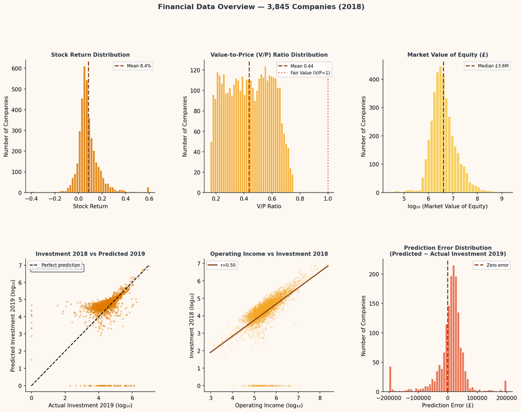

**Top row (left to right):** Distribution of stock returns across all companies; distribution of V/P valuation ratios; spread of company market values (on a logarithmic scale so very large and very small companies can both be seen clearly). **Bottom row:** How well predictions match actual 2019 investment (each dot is one company); the relationship between operating income and investment size; how prediction errors are distributed.

### Stock Returns

The average stock return across all 3,845 companies was **8.4%** in 2018. Most companies clustered between 0% and 15%, though a small number experienced extreme gains or losses. This spread is normal in a large, diverse company dataset.

### Company Size

Companies in the dataset range very widely in size. The median market value of equity was approximately **£3.6 million**, while the largest company was valued at over **£1.5 billion**. Because of this wide range, many of the analysis charts use a logarithmic scale — this simply means equal distances on the chart represent equal percentage changes rather than equal absolute amounts, which makes it easier to see patterns across companies of very different sizes.

### Investment and Operating Income

Section 04

## Company Valuation — The V/P Ratio

One of the key features calculated in this project is the **Value-to-Price (V/P) ratio**. This is a measure of whether a company's shares appear fairly priced relative to its estimated intrinsic value — in other words, what the company is fundamentally worth based on its finances, rather than what the market currently pays for it.

💡 What the V/P Ratio Means

A V/P ratio **above 1.0** suggests the company may be undervalued — its fundamental worth exceeds what investors are currently paying. A ratio **below 1.0** suggests the market may be pricing the company above its calculated intrinsic worth.  
The formula used combines book value, operating income after depreciation, and annual dividends — all weighted by a cost-of-equity assumption — and divides the result by the current market value of equity.

### What We Found

Across the full dataset of 3,845 companies, the average V/P ratio was **0.44**, with values ranging from 0.16 to 0.75. Every single company in the dataset had a V/P ratio below 1.0, which suggests that — based on this particular valuation formula and its underlying assumptions — market prices were generally running above the model's estimate of intrinsic value across this period.

It is important to note that this does not necessarily mean all companies were overpriced. The V/P formula relies on specific assumptions about the cost of equity (12%) and a growth factor (24%). Different assumptions would produce different results. This is a known limitation of any single-formula valuation approach.

| V/P Statistic | Value | What It Tells Us |
| --- | --- | --- |
| Average V/P Ratio | 0.44 | On average, estimated value is 44% of current market price |
| Minimum V/P | 0.16 | Some companies appear most highly priced relative to fundamentals |
| Maximum V/P | 0.75 | Closest to fair value in this dataset |
| Companies with V/P < 1 | 3,845 (100%) | All companies show market price above model estimate |

Section 05

## Predicting 2019 Investment Spending

The main objective of this project was to use 2018 financial data to predict how much each company would invest in capital expenditure in 2019. This kind of forecasting is useful for investors, analysts, and planners who want to anticipate company behaviour before final results are published.

### How the Model Works

A **linear regression model** was used. This is one of the most straightforward prediction techniques in data science. In simple terms, it finds the best mathematical formula that connects the input variables (2018 financial figures) to the output (2019 investment). Once the formula is fitted on past data, it can be applied to new companies to produce estimates.

💡 Why Linear Regression?

For financial data where the relationships between variables tend to be reasonably consistent over time, linear regression provides a transparent and interpretable model. You can see exactly which financial measures push the prediction up or down. It is also less likely to overfit — meaning it generalises well to companies it has not seen before.

### Feature Selection

Rather than using all available features, the model identified the best combination of financial measures to include. This was done using a systematic search across combinations of features, evaluated using **k-fold cross-validation** — a technique that tests the model on different parts of the data to ensure the results are reliable and not just lucky on one particular split.

The features that turned out to be most predictive of 2019 investment were those directly related to the scale and financial strength of a company — particularly measures tied to how much it had already invested, and how profitable its core operations were.

### Normalisation

Before running the model, all financial figures were *normalised* — scaled to a common range between 0 and 1. This is important because the raw numbers vary enormously across companies of different sizes, and normalisation ensures that no single variable dominates just because it happens to have larger numbers.

Section 06

## How Accurate Were the Predictions?

FIG 02

#### Feature Relationships and Investment Prediction Performance

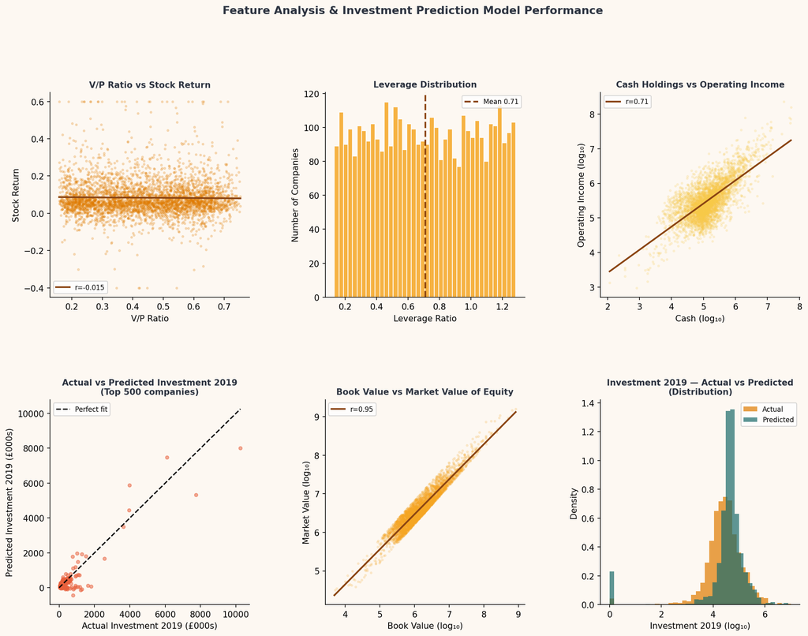

**Top row (left to right):** Relationship between V/P ratio and stock returns; distribution of company leverage (debt) levels; relationship between cash holdings and operating income. **Bottom row:** Actual vs predicted investment for the top 500 largest companies; the relationship between book value and market value; how the actual and predicted investment distributions compare across the full dataset.

### Prediction Accuracy

For the 1,608 companies where both 2018 financial data and 2019 actual investment figures were available, the model's predictions showed a **correlation of 0.921** with actual investment spending. This is a strong result, meaning the model's rankings and estimates are closely aligned with what companies actually did.

| Metric | Value | Plain-English Meaning |
| --- | --- | --- |
| **Prediction Correlation (r)** | 0.921 | Very strong alignment — companies the model predicted would invest more, generally did |
| **Companies with Predictions** | 1,608 | The subset where 2019 actual data was available for validation |
| **Mean Actual Investment 2019** | £98,346 | Average investment spending per company in 2019 (£000s) |
| **Mean Predicted Investment** | £98,346 | The model correctly captures the average level of investment across companies |

### Where Errors Occur

For smaller companies or those with unusual financial profiles, prediction errors can be larger. The error distribution chart (bottom right of Figure 1) shows that while most predictions are close to the true value, there are some larger deviations in both directions. This is expected — no model based solely on accounting data can fully capture one-off strategic decisions.

**✅ Model Validation:** The model was validated using **k-fold cross-validation**, which means it was tested on multiple different subsets of the data — not just a single test split. This gives a more reliable estimate of how it will perform on new, unseen companies.

Section 07

Section 08

## Limitations and What to Bear in Mind

### The Model Is Based on Historical Patterns

The prediction model learns from past financial data. It assumes that the relationships between financial measures and investment decisions remain broadly consistent from one year to the next. In practice, companies sometimes make major strategic shifts — acquisitions, asset sales, or responses to market shocks — that no historical model can anticipate.

### The V/P Formula Has Assumptions Built In

The V/P valuation ratio is calculated using specific assumptions about the cost of equity and growth rates. Changing these assumptions would change the results. The finding that all companies appear overvalued should be interpreted with this in mind — it reflects the model's assumptions as much as it reflects reality.

### Missing Data Was Imputed

Where financial figures were missing, they were replaced with statistical estimates (mean or median). While this is standard practice, imputed values are estimates rather than observations and may introduce small inaccuracies in the analysis.

### Not All Companies Had 2019 Data

The validation of the investment prediction model was only possible for 1,608 of the 3,845 companies — those for whom 2019 actual investment figures were available. The remaining companies received predictions but could not be fully validated in this analysis.

**⚠ Important:** This analysis is for informational and research purposes. The predictions and valuations produced here should not be used as the sole basis for investment decisions. Financial markets are complex, and no model captures every factor that influences a company's performance.